# Data Analysis Using Statistical Packages: Descriptive statistics

Sho Kuroda / 黒田翔

2024年3月 (Last update: 2024年3月)

# 1 Loading data / データの読み込み

タイタニック号乗客データを読み込む．

```r
titanic <- read.csv("https://raw.githubusercontent.com/kurodaecon/bs/main/data/titanic3_csv.csv")
```

# 2 Qualitative data / 質的データ

性別変数 `sex` を例に利用．

## 2.1 Frequency table / 度数分布表

```r
table(titanic$sex)
```

```
##
## female   male
##    466    843
```

`female` と `male` それぞれを数える場合．

```r
head(titanic$sex)
```

```
## [1] "female" "male"   "female" "male"   "female" "male"
```

```r
head(titanic$sex == "female")  # logical ... TRUE or FALSE
```

```
## [1]  TRUE FALSE  TRUE FALSE  TRUE FALSE
```

```r
sum(titanic$sex == "female")  # the number of TRUE = the number of female
```

```
## [1] 466
```

```r
sum(titanic$sex == "male")  # the number of male
```

```
## [1] 843
```

この `table` 関数を利用してデータに欠損値 (NA) があるかを確認するとよい． 欠損値である場合に TRUE を返す関数 `is.na` を併用する．

```r
is.na(c(1, 10, NA, 1000))
```

```
## [1] FALSE FALSE  TRUE FALSE
```

```r
table(is.na(c(1, 10, NA, 1000)))
```

```
##
## FALSE  TRUE
##     3     1
```

```r
table(is.na(titanic$sex))
```

```
##
## FALSE
##  1309
```

## 2.2 Bar chart / 棒グラフ

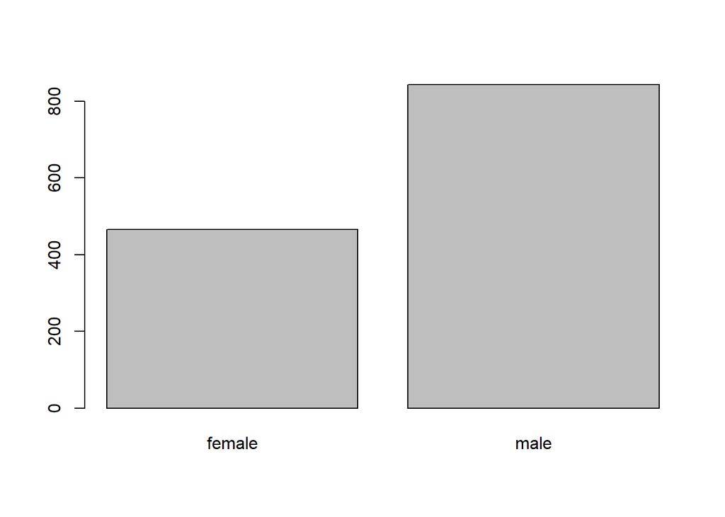

```r
barplot(table(titanic$sex))
```

## 2.3 Pie chart / 円グラフ

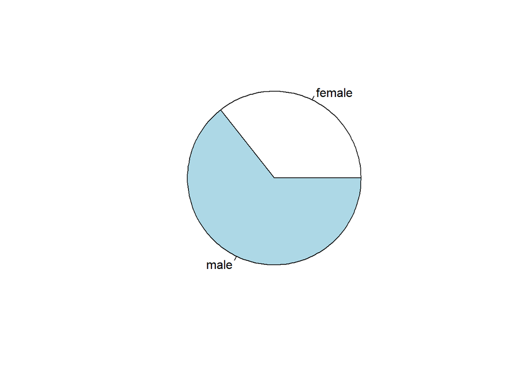

```r
pie(table(titanic$sex))
```

Add percentage to labels.

ラベルに「%」を追加する．

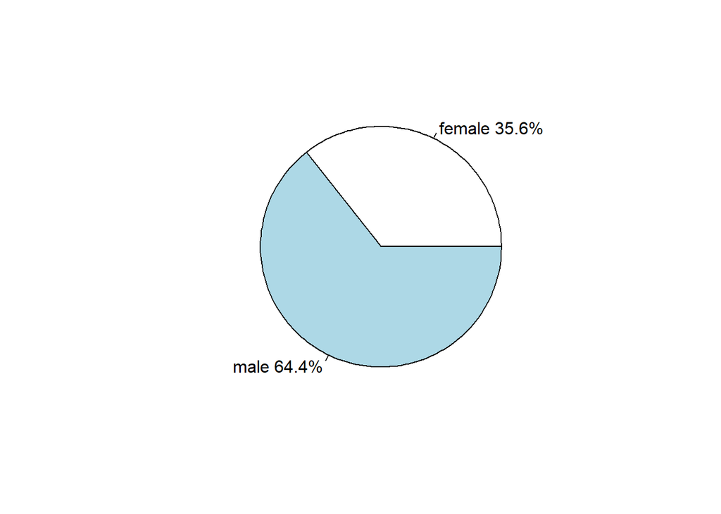

```r
titanic_sex_table <- table(titanic$sex)
titanic_sex_label <- paste(names(titanic_sex_table), " ",
                     round(100 * titanic_sex_table / sum(titanic_sex_table), 1), "%", sep = "")
pie(titanic_sex_table, labels = titanic_sex_label)
```

### 2.3.1 Supplement

上のごちゃごちゃしたコードはどのように動いているのか？

```r
paste("female", " ", 35.6, "%", sep = "")
```

```
## [1] "female 35.6%"
```

```r
titanic_sex_table / sum(titanic_sex_table)
```

```
##
##    female      male
## 0.3559969 0.6440031
```

```r
round(100 * titanic_sex_table / sum(titanic_sex_table), 1)
```

```
##
## female   male
##   35.6   64.4
```

注：ちょっとしたグラフを作成する程度ならExcelの方が便利という場合もよくある．

## 2.4 Contingency table / 分割表

Specify two arguments, e.g., sex and survived, in the `table` function.

```r
table(titanic$sex, titanic$survived)
```

```
##
##            0   1
##   female 127 339
##   male   682 161
```

セルを1つずつカウントすることもできる．

```r
sum(titanic$sex == "female" & titanic$survived == 0)
```

```
## [1] 127
```

```r
sum(titanic$sex == "female" & titanic$survived == 1)
```

```
## [1] 339
```

```r
sum(titanic$sex == "male" & titanic$survived == 0)
```

```
## [1] 682
```

```r
sum(titanic$sex == "male" & titanic$survived == 1)
```

```
## [1] 161
```

## 2.5 Mode / 最頻値

出港地 `embarked` を例として．

```r
table(titanic$embarked)
```

```
##
##       C   Q   S
##   2 270 123 914
```

```r
names(which.max(table(titanic$embarked)))
```

```
## [1] "S"
```

# 3 Quantitative data / 量的データ

年齢変数 `age` を例に利用． 欠損値もある．

```r
head(titanic$age)
```

```
## [1] 29.00  0.92  2.00 30.00 25.00 48.00
```

```r
table(is.na(titanic$age))
```

```
##
## FALSE  TRUE
##  1046   263
```

## 3.1 Histogram / ヒストグラム

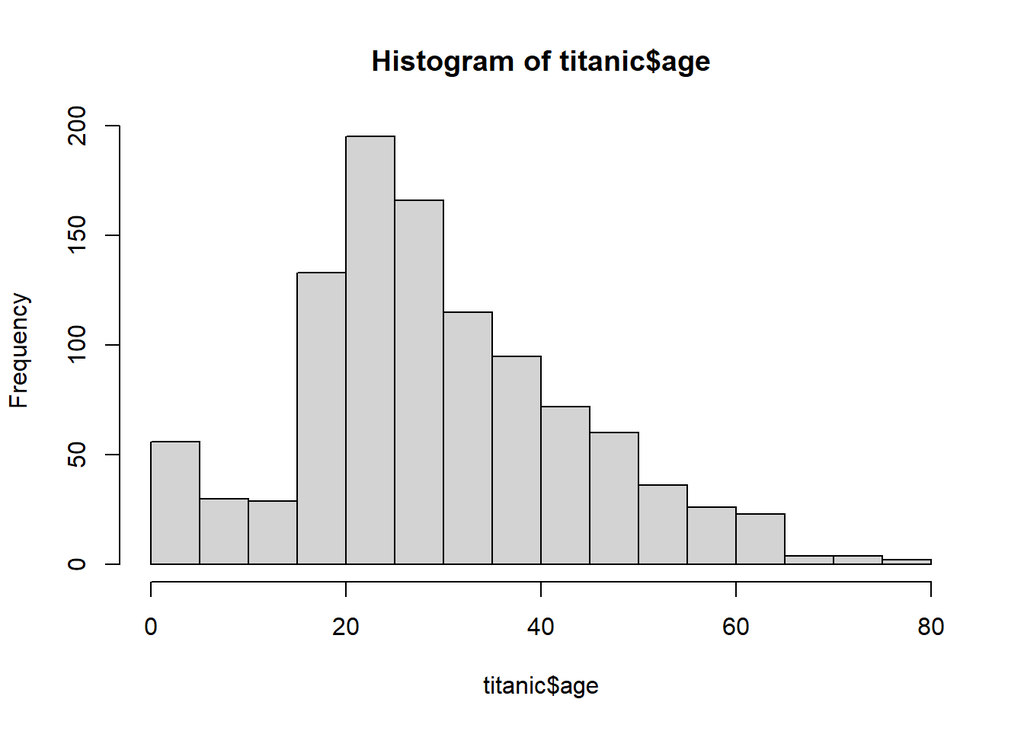

```r
hist(titanic$age)
```

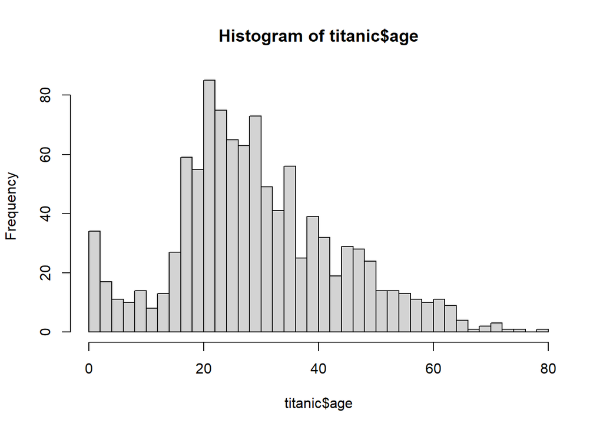

```r
hist(titanic$age, breaks = 30)  # set the number of cells
```

度数ではなく相対度数（全体に占める割合）で表示する場合は `freq = FALSE` という引数を追加する．

滑らかな曲線をフィットさせるには `density` 関数でカーネル密度推定を行って `lines` 関数で重ね描きする．

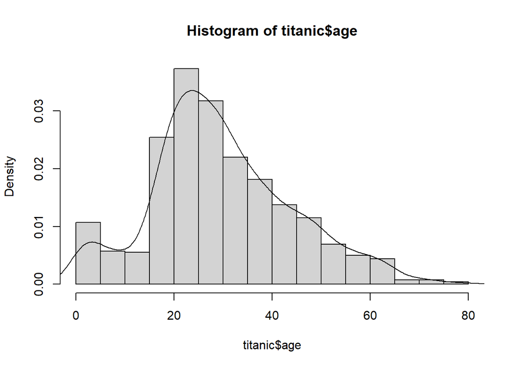

```r
hist(titanic$age, freq = FALSE)
lines(density(titanic$age, na.rm = TRUE))
```

## 3.2 Frequency distribution table of quantitative data / 数量データの度数分布表

[0, 20), [20, 60), [60, 100) の3区間で作成する． そのために，`cut` 関数を利用して実数データを上の3区間に変換する．

```r
titanic_age_interval <- cut(titanic$age, breaks = c(0, 20, 60, 100), right = FALSE)
# [right = F] means intervals should not be closed on the right
table(titanic_age_interval)
```

```
## titanic_age_interval
##   [0,20)  [20,60) [60,100)
##      225      781       40
```

```r
table(titanic_age_interval) / sum(table(titanic_age_interval))  # relative frequency
```

```
## titanic_age_interval
##     [0,20)    [20,60)   [60,100)
## 0.21510516 0.74665392 0.03824092
```

## 3.3 Mean / 平均

$$\bar{x} = \frac{1}{n} \sum_i x_i$$

```r
x <- c(1, 2, 6)
1 + 2 + 6  # sum (1+2+6=9)
```

```
## [1] 9
```

```r
sum(x)  # sum
```

```
## [1] 9
```

```r
sum(x) / 3  # definition of mean
```

```
## [1] 3
```

```r
mean(x)
```

```
## [1] 3
```

```r
mean(c(1, 2, 6))  # same as above / このように書いても同じ結果が得られる
```

```
## [1] 3
```

### 3.3.1 Example of age variable of Titanic data / タイタニック号乗客データの年齢変数

欠損値 `NA` があると計算結果も `NA` になる． その場合は `NA` を除外して平均を計算するために `na.rm = TRUE` 引数を追加する．

```r
mean(titanic$age)
```

```
## [1] NA
```

```r
mean(titanic$age, na.rm = TRUE)
```

```
## [1] 29.88114
```

## 3.4 Quantiles, median / 分位数，中央値

```r
quantile(c(1, 2, 4, 7, 8, 11, 13, 13, 15, 16, 18))  # returns quartiles as default 四分位数
```

```
##   0%  25%  50%  75% 100%
##  1.0  5.5 11.0 14.0 18.0
```

```r
quantile(titanic$age, na.rm = TRUE)
```

```
##    0%   25%   50%   75%  100%
##  0.17 21.00 28.00 39.00 80.00
```

```r
summary(titanic$age)
```

```
##    Min. 1st Qu.  Median    Mean 3rd Qu.    Max.    NA's
##    0.17   21.00   28.00   29.88   39.00   80.00     263
```

The `summary` function also reports the quartiles.

summary関数も四分位点を報告するが，quantile関数を使った場合と少し値が違う場合もある．

```r
quantile(titanic$age, probs = seq(0.1, 0.9, by = 0.1), na.rm = TRUE)  # deciles 十分位数
```

```
## 10% 20% 30% 40% 50% 60% 70% 80% 90%
##  14  19  22  25  28  31  36  42  50
```

```r
quantile(titanic$age, probs = 0.35, na.rm = TRUE)  # 35th percentile
```

```
## 35%
##  24
```

```r
median(titanic$age, na.rm = TRUE)  # median 中央値
```

```
## [1] 28
```

## 3.5 Maximum, Minimum, Range / 最大値，最小値，範囲

```r
max(titanic$age); min(titanic$age)
```

```
## [1] NA
```

```
## [1] NA
```

```r
max(titanic$age, na.rm = TRUE); min(titanic$age, na.rm = TRUE)
```

```
## [1] 80
```

```
## [1] 0.17
```

```r
max(titanic$age, na.rm = TRUE) - min(titanic$age, na.rm = TRUE)  # range
```

```
## [1] 79.83
```

## 3.6 Variance and standard deviation / 分散と標準偏差

$$s^2 = \frac{1}{n-1} \sum_i (x_i -
\bar{x})^2, \quad s = \sqrt{s^2}$$

```r
x <- c(1, 2, 6)
x - 3
```

```
## [1] -2 -1  3
```

```r
x - mean(x)
```

```
## [1] -2 -1  3
```

```r
(x - mean(x))^2
```

```
## [1] 4 1 9
```

```r
mean((x - mean(x))^2)  # definition of population variance
```

```
## [1] 4.666667
```

```r
sum((x - mean(x))^2) / 3  # same as above
```

```
## [1] 4.666667
```

```r
sum((x - mean(x))^2) / (3-1)  # definition of sample variance (unbiased variance)
```

```
## [1] 7
```

```r
var(x)  # variance defined as sample variance
```

```
## [1] 7
```

```r
sqrt(var(x))  # definition of standard deviation
```

```
## [1] 2.645751
```

```r
sd(x)
```

```
## [1] 2.645751
```

### 3.6.1 Example of dice roll

Expected value and variance of the dice roll.

サイコロの出目の期待値と分散

$$E(X) = \sum_j^k x_j f(x_j), \quad V(X)
= E[(X-E(X))^2] = \sum_j^k (x_j - E(X))^2 f(x_j) = E(X^2) - (E(X))^2$$

```r
dice <- 1:6  # c(1, 2, 3, 4, 5, 6) と同じ
sum(dice * (1/6))  # definition of expectation
```

```
## [1] 3.5
```

```r
mean(dice)  # mean
```

```
## [1] 3.5
```

```r
sum((dice - mean(dice))^2 * (1/6))  # variance: sum[(x-E(X))*f(x)]
```

```
## [1] 2.916667
```

```r
sum(dice^2 * (1/6)) - sum(dice * (1/6))^2  # variance: E(X^2)-E(X)^2
```

```
## [1] 2.916667
```

The value of `var(dice)` is 3.5, which does not equal the above, but this is because the `var` function calculates the sample variance (unbiased variance); `3.5*(n-1)/n = 3.5*5/6 ≈ 2.9`.

なお `var(dice)` を計算すると3.5となり，上記と一致しないが，これは `var` 関数が標本分散（不偏分散）を計算するためである．`3.5*(n-1)/n = 3.5*5/6 ≒ 2.9` である．

### 3.6.2 Example of age variable of Titanic data / タイタニック号乗客データの年齢変数

欠損値 `NA` があると計算結果も `NA` になる． その場合は `NA` を除外して平均を計算するために `na.rm = TRUE` 引数を追加する．

```r
var(titanic$age)
```

```
## [1] NA
```

```r
var(titanic$age, na.rm = TRUE)
```

```
## [1] 207.7488
```

```r
sd(titanic$age, na.rm = TRUE)
```

```
## [1] 14.41349
```

### 3.6.3 Box plot / 箱ひげ図

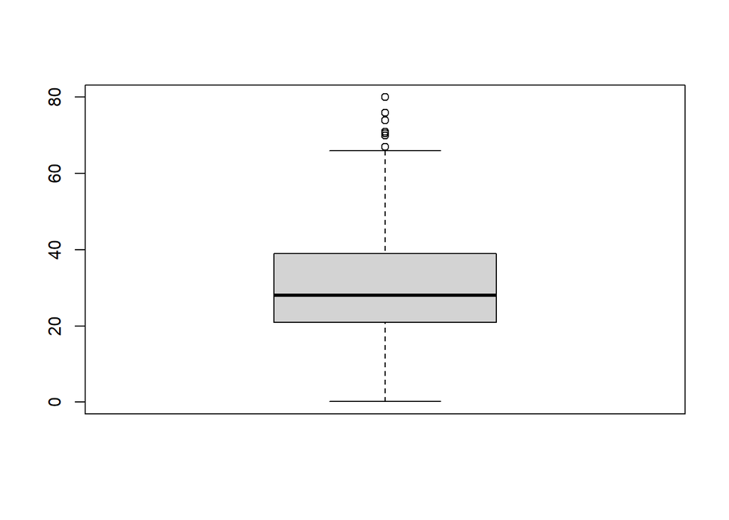

```r
boxplot(titanic$age)
```

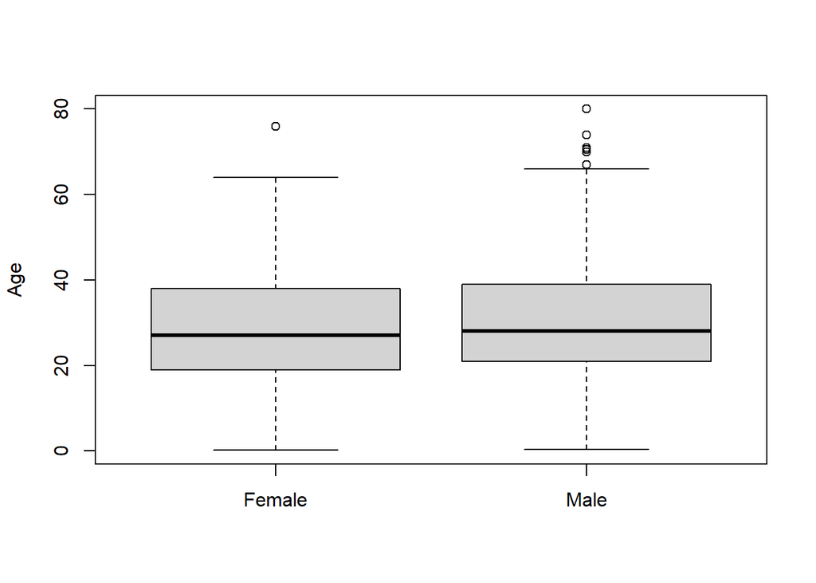

```r
titanic_age_female <- titanic$age[titanic$sex == "female"]  # age of female
titanic_age_male <- titanic$age[titanic$sex == "male"]  # age of male
boxplot(titanic_age_female, titanic_age_male, names = c("Female", "Male"), ylab = "Age")
```

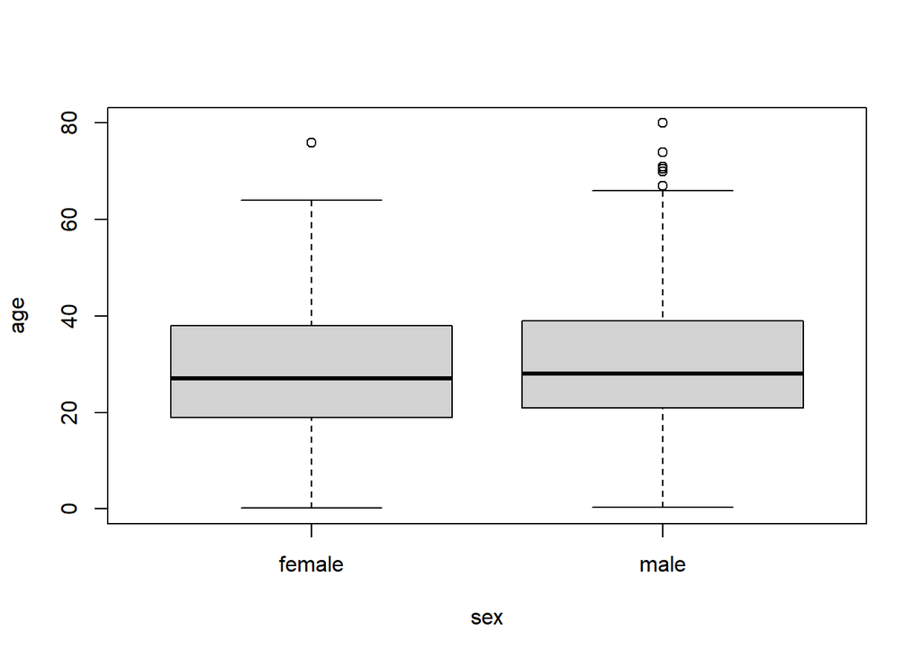

```r
boxplot(age ~ sex, titanic)  # same as above
```

## 3.7 Scatter plot / 散布図

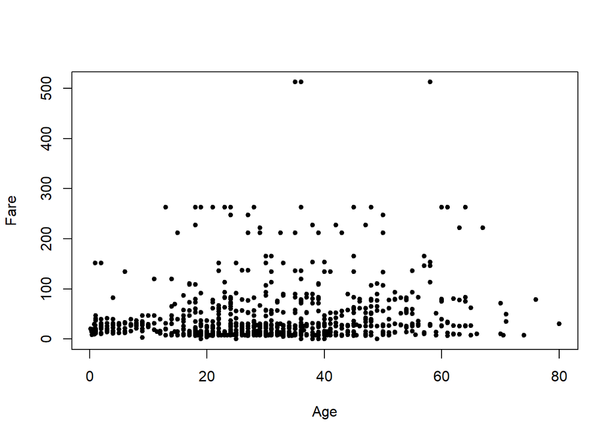

```r
plot(x = titanic$age, y = titanic$fare, xlab = "Age", ylab = "Fare", pch = 20)
```

### 3.7.1 Scale does matter

Same data but difference scale (on y-axis).

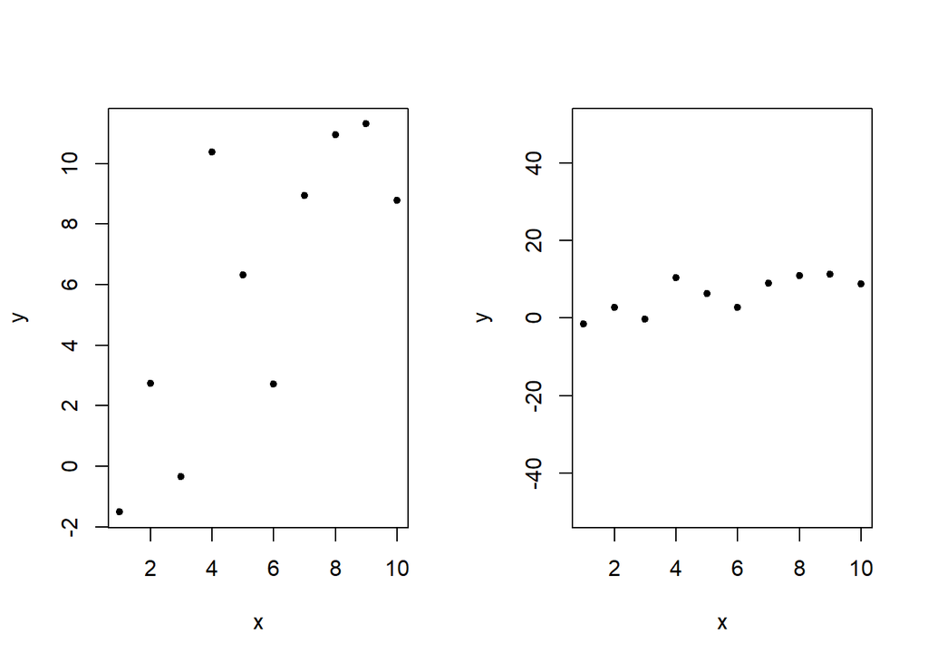

```r
tempx <- 1:10
set.seed(1)
tempy <- tempx + rnorm(10, sd = 4)
par(mfrow = c(1, 2))
plot(tempx, tempy, xlab = "x", ylab = "y", pch = 20)
plot(tempx, tempy, xlab = "x", ylab = "y", pch = 20, ylim = c(-50, 50))
```

The left figure appears to show a positive correlation, while the right figure will look uncorrelated.

左の図は正の相関を示しているように見えるが，右の図は無相関に見えるだろう．

### 3.7.2 Non-linear relationship

Y軸のみ対数変換する場合は `log = "y"`，X軸とY軸の両方を対数変換する場合は `log = "xy"` を引数に追加する．

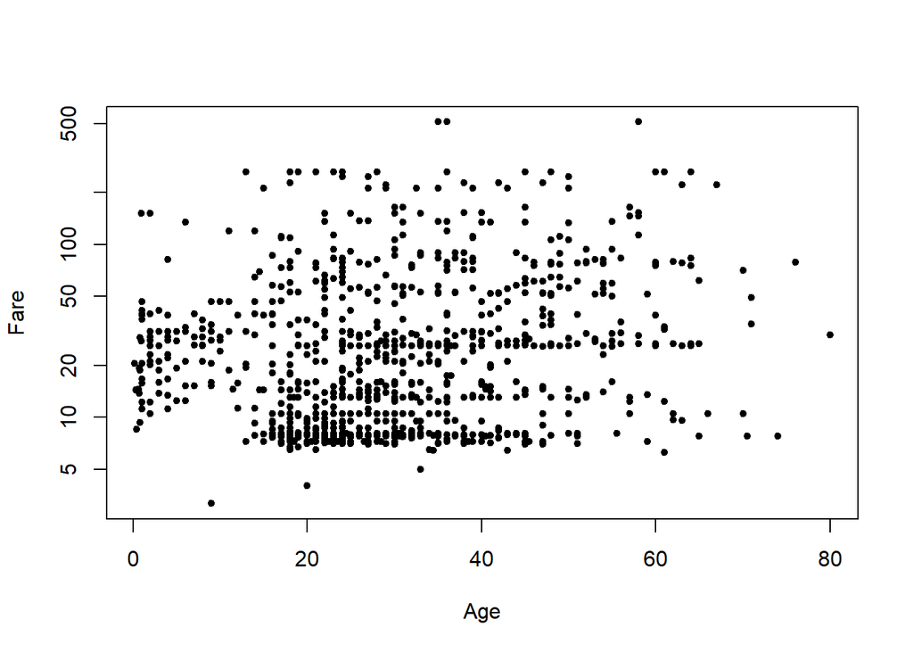

```r
plot(x = titanic$age, y = titanic$fare, xlab = "Age", ylab = "Fare", pch = 20, log = "y")
```

### 3.7.3 Data points overlap

`col = "red"` のように引数を追加することでマーカーの色を指定できる．

`col = rgb(red, green, blue)` のように引数を追加すれば，RGB形式で色を指定できる．

`col = rgb(red, green, blue, alpha)` のように引数を追加すれば，RGB形式で色を指定したうえに，透過水準を alpha 値（0以上1以下）として指定できる．

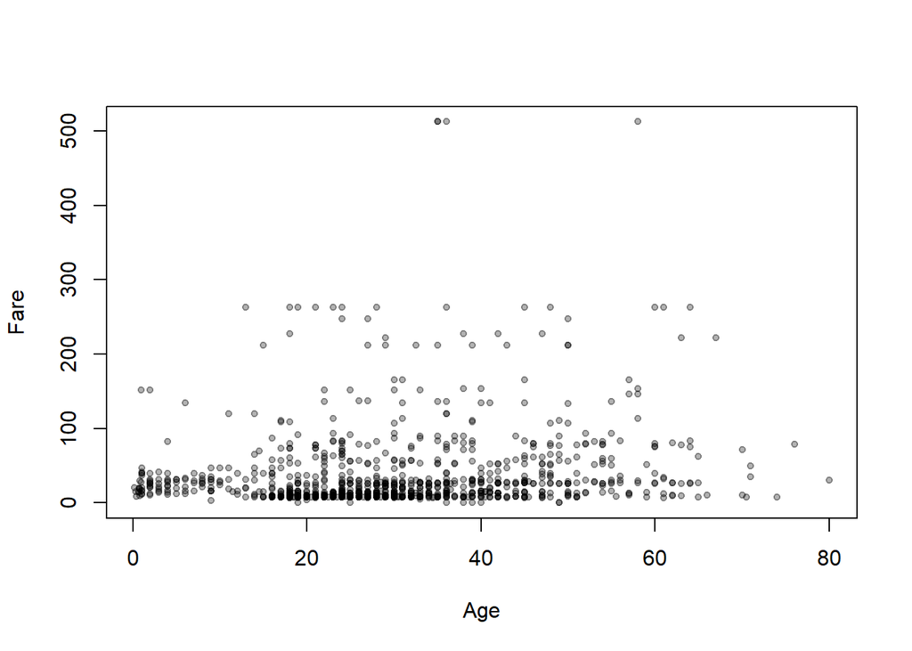

```r
plot(x = titanic$age, y = titanic$fare, xlab = "Age", ylab = "Fare", pch = 20, col = rgb(0, 0, 0, .3))
```

### 3.7.4 Scatter plot with jitter

Without jitter

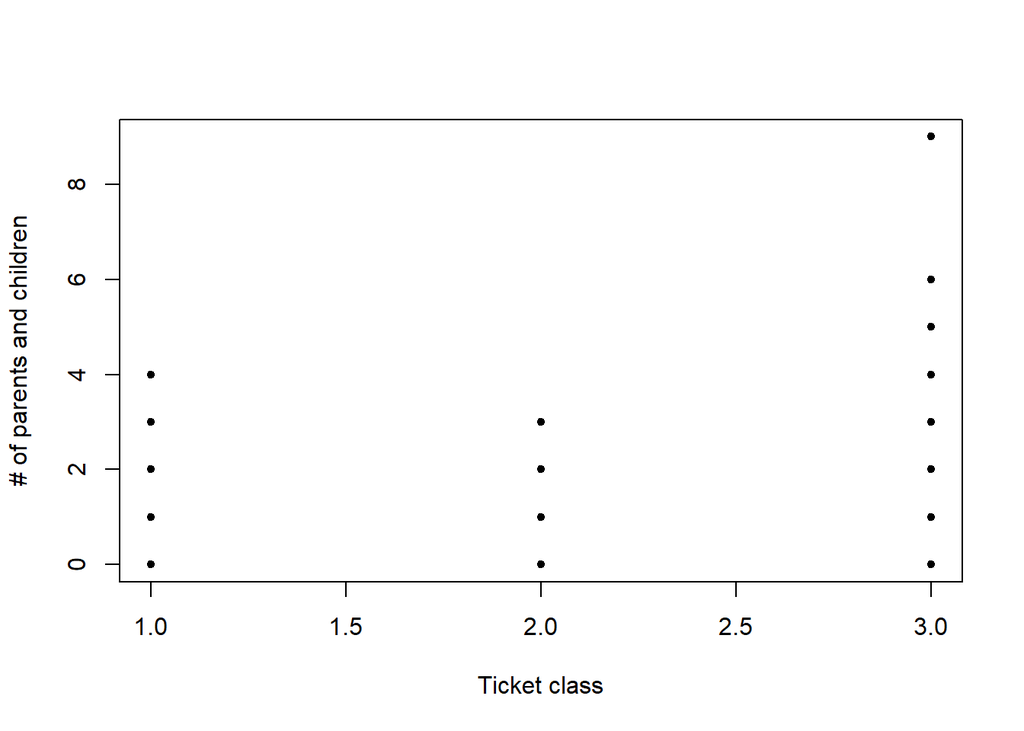

```r
plot(x = titanic$pclass, y = titanic$parch, xlab = "Ticket class",
     ylab = "# of parents and children", pch = 20)
```

With jitter

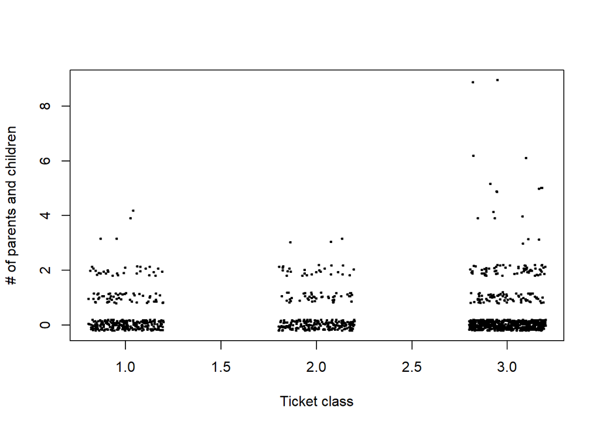

```r
plot(x = jitter(titanic$pclass), y = jitter(titanic$parch), xlab = "Ticket class",
     ylab = "# of parents and children", pch = 20, cex = .5)
```

### 3.7.5 Binned scatter plot

Raw plot

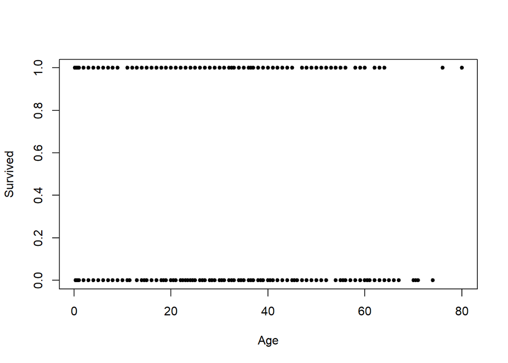

```r
plot(x = titanic$age, y = titanic$survived, xlab = "Age", ylab = "Survived", pch = 20)
```

Binned plot

```r
titanic_with_age <- titanic[!is.na(titanic$age), ]  # remove obs. with no age
titanic_age_6 <- cut(titanic_with_age$age, breaks = 6)  # convert age into 6 intervals
levels(titanic_age_6)
```

```
## [1] "(0.0902,13.5]" "(13.5,26.8]"   "(26.8,40.1]"   "(40.1,53.4]"
## [5] "(53.4,66.7]"   "(66.7,80.1]"
```

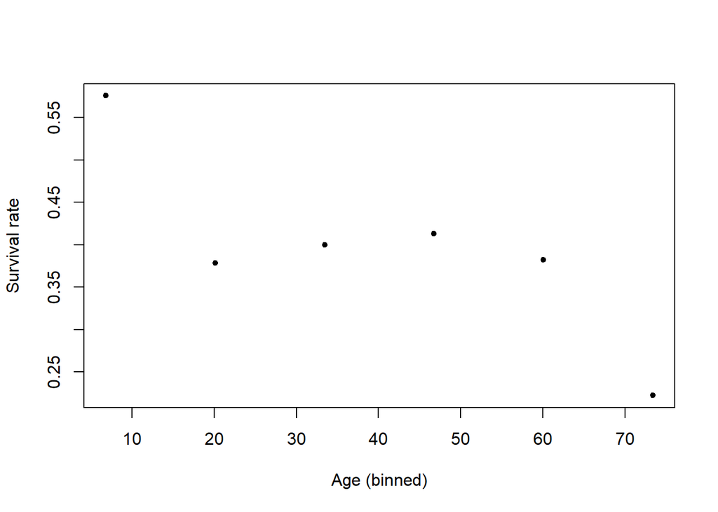

```r
titanic_mean_age <- c((0.0902+13.5)/2, (13.5+26.8)/2, (26.8+40.1)/2,
                      (40.1+53.4)/2, (53.4+66.7)/2, (66.7+80.1)/2)
titanic_mean_survived <- c(
 mean(titanic_with_age$survived[titanic_age_6 == levels(titanic_age_6)[1]]),
 mean(titanic_with_age$survived[titanic_age_6 == levels(titanic_age_6)[2]]),
 mean(titanic_with_age$survived[titanic_age_6 == levels(titanic_age_6)[3]]),
 mean(titanic_with_age$survived[titanic_age_6 == levels(titanic_age_6)[4]]),
 mean(titanic_with_age$survived[titanic_age_6 == levels(titanic_age_6)[5]]),
 mean(titanic_with_age$survived[titanic_age_6 == levels(titanic_age_6)[6]]) )
plot(x = titanic_mean_age, y = titanic_mean_survived,
     xlab = "Age (binned)", ylab = "Survival rate", pch = 20)
```

注：Binned plot を計算するための便利なパッケージが幾つかあるため，実際に描画する際にはそれを利用するとよい．

### 3.7.6 Scatterplot Matrix / 散布図行列

3つ以上の連続変数の散布図の組み合わせを行列形式で表示する． Draftman’s display や Pair plot とも呼ばれる．

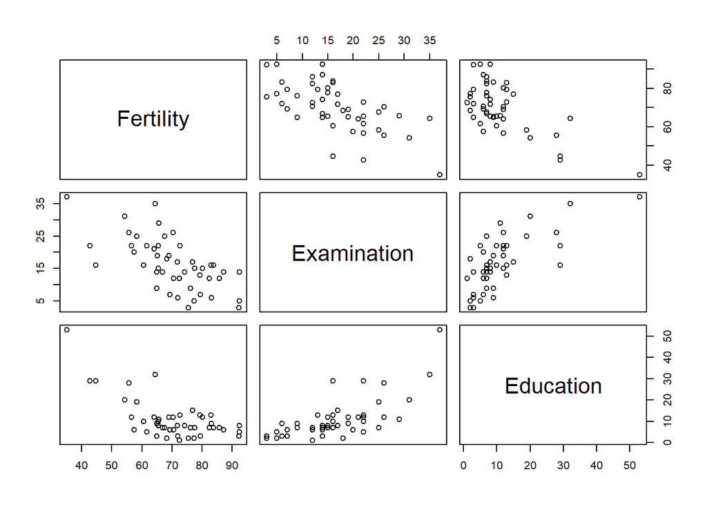

```r
pairs(swiss[, c("Fertility", "Examination", "Education")])
```

## 3.8 Covariance and correlation / 共分散と相関係数

$$Cov(x, y) = \frac{1}{n-1} \sum_i (x_i -
\bar{x})(y_i - \bar{y})$$

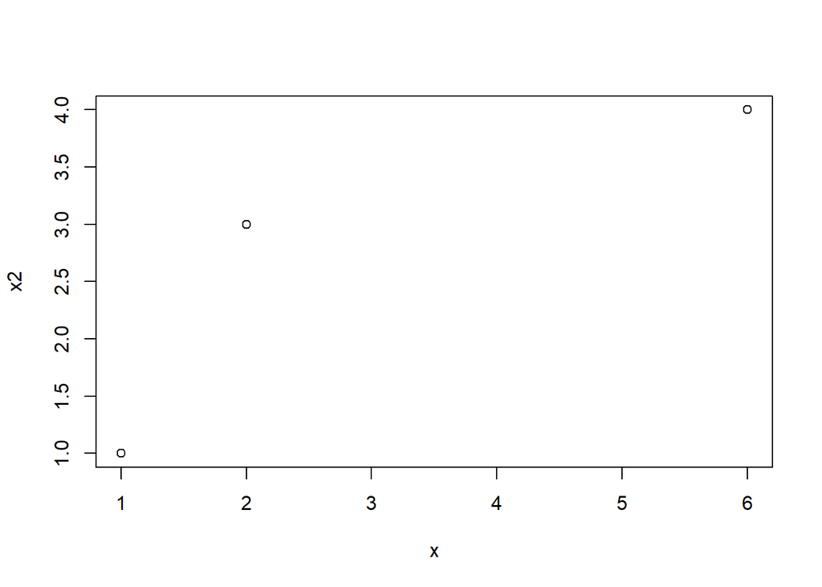

```r
x <- c(1, 2, 6)
x2 <- c(1, 3, 4)
plot(x, x2)  # scatter plot
```

```r
(x - mean(x)) * (x2 - mean(x2))
```

```
## [1]  3.3333333 -0.3333333  4.0000000
```

```r
sum((x - mean(x)) * (x2 - mean(x2))) / 3  # definition of sample covariance
```

```
## [1] 2.333333
```

```r
sum((x - mean(x)) * (x2 - mean(x2))) / (3-1)  # definition of sample covariance
```

```
## [1] 3.5
```

```r
cov(x, x2)  # covariance of unbiased covariance
```

```
## [1] 3.5
```

$$Cor(x, y) = \frac{Cov(x,
y)}{\sqrt{V(x)} \cdot \sqrt{V(y)}}$$

```r
cov(x, x2) / (sd(x) * sd(x2))  # definition of correlation coef.
```

```
## [1] 0.8660254
```

```r
cor(x, x2)  # correlation coefficient
```

```
## [1] 0.8660254
```

Correlation coefficients of 1 or -1 are obtained when one variable is a constant multiple or constant addition of the other variable.

相関係数が 1 や -1 になるのは，一方の変数がもう一方の変数の定数倍・定数加算によって得られるような場合です．

```r
x3 <- x * 2 + 3
x4 <- x * (-0.5) + 3
var(x3); 2^2 * var(x)  # These two should have the same value / この2つは同じ値になるはず
```

```
## [1] 28
```

```
## [1] 28
```

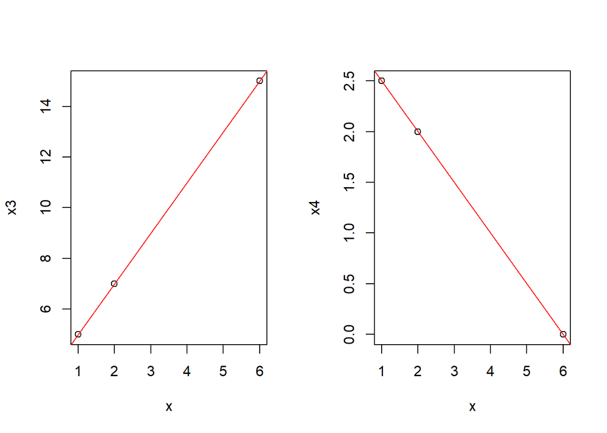

```r
par(mfrow = c(1, 2))
plot(x, x3); abline(lm(x3 ~ x), col = "red")  # Add regression line (red line) / 回帰直線を追加
plot(x, x4); abline(lm(x4 ~ x), col = "red")
```

```r
cor(x, x3)
```

```
## [1] 1
```

```r
cor(x, x4)
```

```
## [1] -1
```

### 3.8.1 Anscombe’s quartet / アンスコムの数値例

See https://en.wikipedia.org/wiki/Anscombe%27s_quartet

Four sets of variables {x, y} are included, whose mean, variance, and correlation coefficients are approximately the same, although the relationship between the variables is different from each other.

変数の関係が互いに異なるが平均・分散・相関係数が概ね同じ {x, y} という変数の組が4セット含まれる．

```r
str(anscombe)  # display structure of object
```

```
## 'data.frame':    11 obs. of  8 variables:
##  $ x1: num  10 8 13 9 11 14 6 4 12 7 ...
##  $ x2: num  10 8 13 9 11 14 6 4 12 7 ...
##  $ x3: num  10 8 13 9 11 14 6 4 12 7 ...
##  $ x4: num  8 8 8 8 8 8 8 19 8 8 ...
##  $ y1: num  8.04 6.95 7.58 8.81 8.33 ...
##  $ y2: num  9.14 8.14 8.74 8.77 9.26 8.1 6.13 3.1 9.13 7.26 ...
##  $ y3: num  7.46 6.77 12.74 7.11 7.81 ...
##  $ y4: num  6.58 5.76 7.71 8.84 8.47 7.04 5.25 12.5 5.56 7.91 ...
```

```r
summary(anscombe)
```

```
##        x1             x2             x3             x4           y1
##  Min.   : 4.0   Min.   : 4.0   Min.   : 4.0   Min.   : 8   Min.   : 4.260
##  1st Qu.: 6.5   1st Qu.: 6.5   1st Qu.: 6.5   1st Qu.: 8   1st Qu.: 6.315
##  Median : 9.0   Median : 9.0   Median : 9.0   Median : 8   Median : 7.580
##  Mean   : 9.0   Mean   : 9.0   Mean   : 9.0   Mean   : 9   Mean   : 7.501
##  3rd Qu.:11.5   3rd Qu.:11.5   3rd Qu.:11.5   3rd Qu.: 8   3rd Qu.: 8.570
##  Max.   :14.0   Max.   :14.0   Max.   :14.0   Max.   :19   Max.   :10.840
##        y2              y3              y4
##  Min.   :3.100   Min.   : 5.39   Min.   : 5.250
##  1st Qu.:6.695   1st Qu.: 6.25   1st Qu.: 6.170
##  Median :8.140   Median : 7.11   Median : 7.040
##  Mean   :7.501   Mean   : 7.50   Mean   : 7.501
##  3rd Qu.:8.950   3rd Qu.: 7.98   3rd Qu.: 8.190
##  Max.   :9.260   Max.   :12.74   Max.   :12.500
```

```r
mean(anscombe$x1)
```

```
## [1] 9
```

```r
apply(anscombe, 2, mean)  # mean
```

```
##       x1       x2       x3       x4       y1       y2       y3       y4
## 9.000000 9.000000 9.000000 9.000000 7.500909 7.500909 7.500000 7.500909
```

```r
apply(anscombe, 2, var)  # variance
```

```
##        x1        x2        x3        x4        y1        y2        y3        y4
## 11.000000 11.000000 11.000000 11.000000  4.127269  4.127629  4.122620  4.123249
```

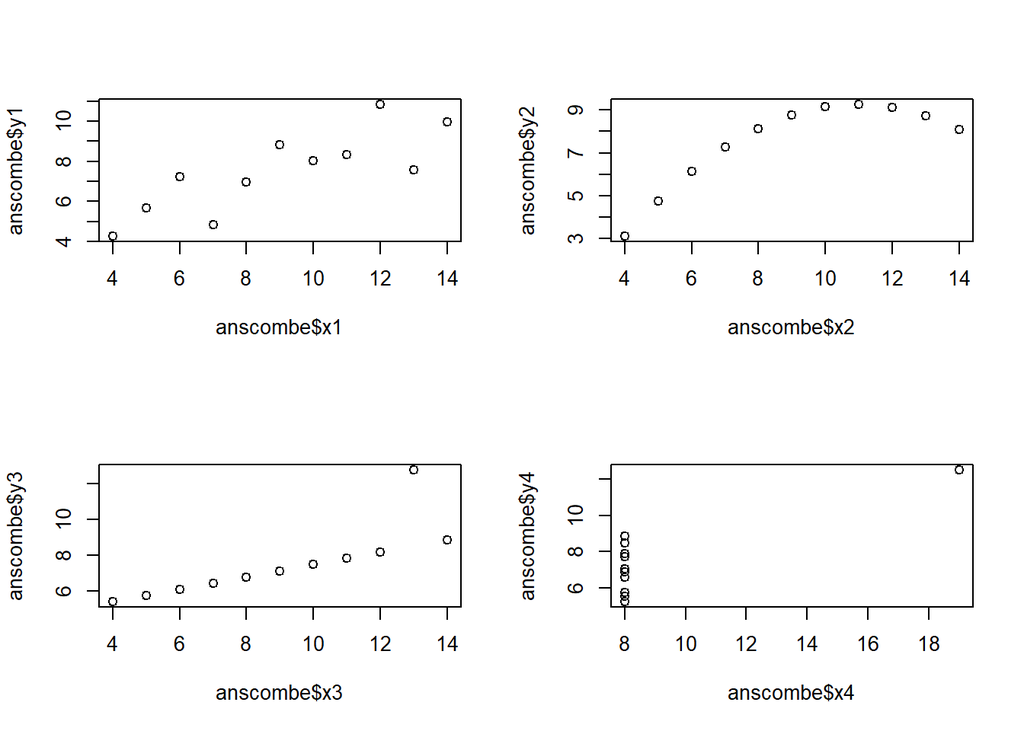

```r
par(mfrow = c(2, 2))
plot(anscombe$x1, anscombe$y1)
plot(anscombe$x2, anscombe$y2)
plot(anscombe$x3, anscombe$y3)
plot(anscombe$x4, anscombe$y4)
```

```r
cor(anscombe$x1, anscombe$y1)  # correlation of x1 and y1
```

```
## [1] 0.8164205
```

```r
cor(anscombe$x2, anscombe$y2)
```

```
## [1] 0.8162365
```

```r
cor(anscombe$x3, anscombe$y3)
```

```
## [1] 0.8162867
```

```r
cor(anscombe$x4, anscombe$y4)
```

```
## [1] 0.8165214
```

This example shows us the importance of drawing raw data, rather than just looking at descriptive statistics.

この例は，記述統計だけを見るのではなく，生のデータを描画することの重要性を我々に教えてくれる．

See also: Same Stats, Different Graphs https://www.research.autodesk.com/publications/same-stats-different-graphs/

### 3.8.2 Example of age variable of Titanic data / タイタニック号乗客データの年齢変数

少なくとも一方の変数に欠損値 `NA` がある場合は，欠損値がない観測値のみを使って相関係数を計算するために `use = "complete.obs"` 引数を追加する．

```r
cor(titanic$age, titanic$fare, use = "complete.obs")
```

```
## [1] 0.1787399
```

.